# Tugas MPDW Pertemuan 3

Abdullah Zeith Alfarizy (G1401231060)

2025-09-14

# Library yang Digunakan

```r
library(dLagM)
library(dynlm)
library(MLmetrics)
library(lmtest)
library(car)
```

```r
library(corrplot)
library(tseries)
```

# Impor Data

```r
dataair <- rio::import("https://raw.githubusercontent.com/zeith001/mpdw/main/Pertemuan%203/NewDelhi_Air_quality.csv")
str(dataair)
```

```
## 'data.frame':    72 obs. of  12 variables:
##  $ V1             : int  0 1 2 3 4 5 6 7 8 9 ...
##  $ AQI            : num  30.2 28.2 26.6 25 26 26 26 24 23 24 ...
##  $ CO             : num  199 198 199 202 205 ...
##  $ datetime       : chr  "2022-10-21:18" "2022-10-21:19" "2022-10-21:20" "2022-10-21:21" ...
##  $ no2            : num  0.0469 0.0465 0.0469 0.0482 0.0489 ...
##  $ o3             : num  55.8 54.9 54.6 55.1 55.8 ...
##  $ pm10           : num  10.5 10.7 11.2 11.1 10.4 ...
##  $ pm25           : num  5.64 4.62 3.52 2.23 1.98 ...
##  $ so2            : num  0.387 0.41 0.402 0.376 0.339 ...
##  $ timestamp_local: POSIXct, format: "2022-10-21 23:00:00" "2022-10-22 00:00:00" ...
##  $ timestamp_utc  : POSIXct, format: "2022-10-21 18:00:00" "2022-10-21 19:00:00" ...
##  $ ts             : int  1666375200 1666378800 1666382400 1666386000 1666389600 1666393200 1666396800 1666400400 1666404000 1666407600 ...
```

```r
head(dataair)
```

```
##   V1  AQI       CO      datetime        no2       o3      pm10     pm25
## 1  0 30.2 198.6027 2022-10-21:18 0.04685717 55.78995 10.486722 5.637410
## 2  1 28.2 197.6013 2022-10-21:19 0.04645554 54.93164 10.719325 4.618169
## 3  2 26.6 198.6027 2022-10-21:20 0.04685717 54.64554 11.155578 3.520902
## 4  3 25.0 201.9405 2022-10-21:21 0.04819594 55.07469 11.116206 2.225919
## 5  4 26.0 205.2784 2022-10-21:22 0.04886533 55.78995 10.405250 1.979471
## 6  5 26.0 208.6163 2022-10-21:23 0.05020411 56.50520  9.402518 1.792677
##         so2     timestamp_local       timestamp_utc         ts
## 1 0.3874302 2022-10-21 23:00:00 2022-10-21 18:00:00 1666375200
## 2 0.4097819 2022-10-22 00:00:00 2022-10-21 19:00:00 1666378800
## 3 0.4023313 2022-10-22 01:00:00 2022-10-21 20:00:00 1666382400
## 4 0.3762543 2022-10-22 02:00:00 2022-10-21 21:00:00 1666386000
## 5 0.3390014 2022-10-22 03:00:00 2022-10-21 22:00:00 1666389600
## 6 0.3129244 2022-10-22 04:00:00 2022-10-21 23:00:00 1666393200
```

Data tersebut merupakan data Air Quality Index (AQI) atau indeks kualitas udara yang merupakan pengukuran konsentrasi polutan udara dalam udara ambien dan risiko kesehatan terkait. AQI mengukur 6 polutan yaitu CO, no2, o3, pm10, pm25, dan so2. Dalam data tersebut terdapat 72 periode waktu dan AQI diukur 1 jam sekali. AQI akan digunakan sebagai variabel Y dan 6 polutan pembentuk AQI akan digunakan sebagai variabel X pada analisis selanjutnya.

## Menghapus Kolom yang Tidak Digunakan

```r
dfair <-  dataair[,-c(1, 4, 10, 11, 12)]
```

## Melihat Nilai Korelasi Y dan Setiap X

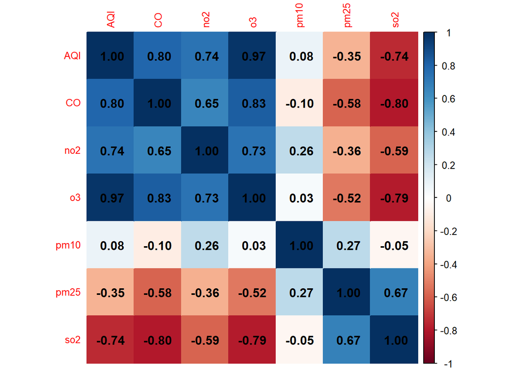

```r
cor_matrix <- cor(dfair[, c("AQI","CO","no2","o3","pm10", "pm25", "so2")])
corrplot(cor_matrix, method="color", addCoef.col="black", tl.cex=0.8)
```

Berdasarkan heatmap korelasi terlihat bahwa variabel Y(AQI) memiliki hubungan paling kuat dengan o3 dengan korelasi positif sebesar 0.97. Maka o3 selanjutnya akan saya gunakan sebagai variabel Xt dalam analisis deret waktu dengan peubah lag.

## Membuat Data Frame Baru

```r
dt_air <- dfair[, c("AQI", "o3")]
colnames(dt_air) <- c("Yt", "Xt")
dt_air$t <- 1:72
dt_air$`Y(t-1)` <- c(NA, head(dt_air$Yt, -1))
head(dt_air)
```

```
##     Yt       Xt t Y(t-1)
## 1 30.2 55.78995 1     NA
## 2 28.2 54.93164 2   30.2
## 3 26.6 54.64554 3   28.2
## 4 25.0 55.07469 4   26.6
## 5 26.0 55.78995 5   25.0
## 6 26.0 56.50520 6   26.0
```

Yt = AQI Xt = o3

# Eksplorasi Data

## Plot Yt dan Xt

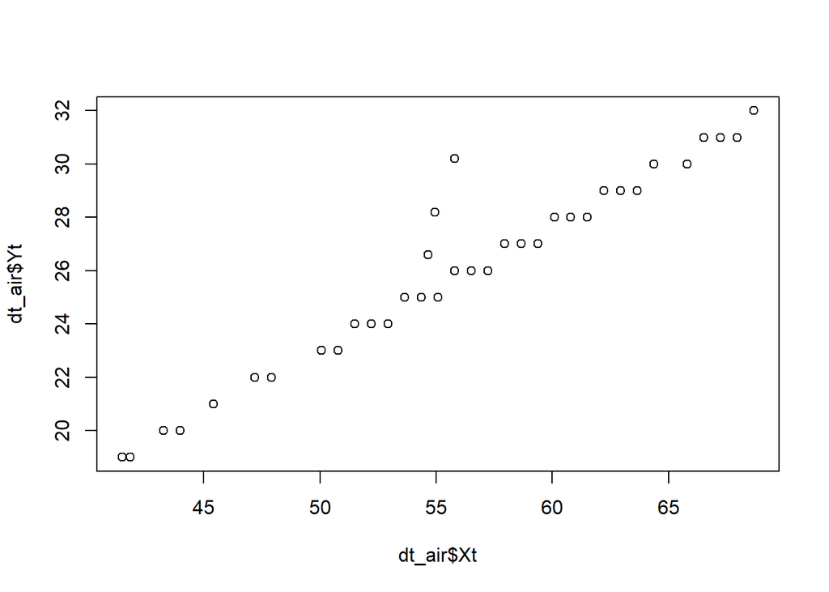

```r
plot(dt_air$Xt, dt_air$Yt)
```

```r
str(dt_air)
```

```
## 'data.frame':    72 obs. of  4 variables:
##  $ Yt    : num  30.2 28.2 26.6 25 26 26 26 24 23 24 ...
##  $ Xt    : num  55.8 54.9 54.6 55.1 55.8 ...
##  $ t     : int  1 2 3 4 5 6 7 8 9 10 ...
##  $ Y(t-1): num  NA 30.2 28.2 26.6 25 26 26 26 24 23 ...
```

```r
dim(dt_air)
```

```
## [1] 72  4
```

```r
summary(dt_air)
```

```
##        Yt              Xt              t             Y(t-1)
##  Min.   :19.00   Min.   :41.48   Min.   : 1.00   Min.   :19.00
##  1st Qu.:25.00   1st Qu.:53.64   1st Qu.:18.75   1st Qu.:25.00
##  Median :27.00   Median :57.22   Median :36.50   Median :27.00
##  Mean   :26.18   Mean   :56.57   Mean   :36.50   Mean   :26.15
##  3rd Qu.:28.00   3rd Qu.:60.08   3rd Qu.:54.25   3rd Qu.:28.00
##  Max.   :32.00   Max.   :68.66   Max.   :72.00   Max.   :32.00
##                                                  NA's   :1
```

## Plot time series Yt dan Xt

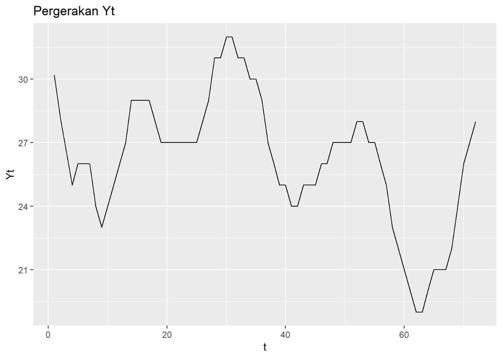

```r
library(ggplot2)
ggplot(dt_air, aes(x=t, y=Yt)) + geom_line() + ggtitle("Pergerakan Yt")
```

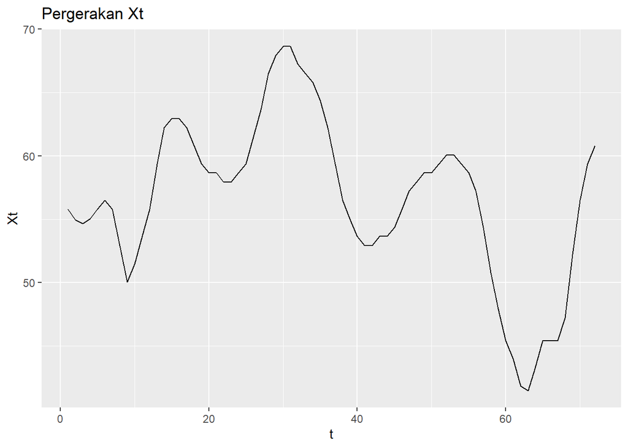

```r
ggplot(dt_air, aes(x=t, y=Xt)) + geom_line() + ggtitle("Pergerakan Xt")
```

## Pembagian Data

```r
#SPLIT DATA
train<-dt_air[1:54,]
test<-dt_air[55:72,]
```

```r
#data time series
train.ts<-ts(train)
test.ts<-ts(test)
dt_air.ts<-ts(dt_air)
```

# Model Koyck

```r
#MODEL KOYCK
model.koyck <- koyckDlm(x = train$Xt, y = train$Yt)
summary(model.koyck)
```

```
##
## Call:
## "Y ~ (Intercept) + Y.1 + X.t"
##
## Residuals:
##       Min        1Q    Median        3Q       Max
## -1.135845 -0.266174  0.005908  0.250093  1.063969
##
## Coefficients:
##             Estimate Std. Error t value Pr(>|t|)
## (Intercept)  0.61475    0.92829   0.662    0.511
## Y.1          0.40694    0.07979   5.100 5.25e-06 ***
## X.t          0.26339    0.03991   6.600 2.54e-08 ***
## ---
## Signif. codes:  0 '***' 0.001 '**' 0.01 '*' 0.05 '.' 0.1 ' ' 1
##
## Residual standard error: 0.5015 on 50 degrees of freedom
## Multiple R-Squared: 0.9489,  Adjusted R-squared: 0.9468
## Wald test: 423.5 on 2 and 50 DF,  p-value: < 2.2e-16
##
## Diagnostic tests:
## NULL
##
##                             alpha      beta       phi
## Geometric coefficients:  1.036564 0.2633856 0.4069377
```

```r
AIC(model.koyck)
```

```
## [1] 82.16805
```

```r
BIC(model.koyck)
```

```
## [1] 90.04921
```

**Interpretasi Hasil:** Dari `summary`, kita mendapatkan model:

[output not shown]

- Koefisien $Y_{t−1}$ (0.40694) juga signifikan. Ini adalah **estimasi untuk** $\lambda$. Nilai ini menunjukkan bahwa sekitar 40.7% dari efek di periode sebelumnya masih “terbawa” ke periode saat ini.

## Peramalan dan Akurasi

Peramalan 18 periode kedepan dengan model koyck :

```r
fore.koyck <- forecast(model = model.koyck, x=test$Xt, h=18)
fore.koyck
```

```
## $forecasts
##  [1] 27.04989 26.69341 25.79480 24.48718 23.20150 22.01896 21.16096 20.24664
##  [9] 19.78038 20.06161 20.74121 21.01777 21.13031 21.64708 23.17609 24.92863
## [17] 26.39536 27.36900
##
## $call
## forecast.koyckDlm(model = model.koyck, x = test$Xt, h = 18)
##
## attr(,"class")
## [1] "forecast.koyckDlm" "dLagM"
```

```r
mape.koyck <- MAPE(fore.koyck$forecasts, test$Yt)
mape.koyck #data test
```

```
## [1] 0.03065559
```

```r
#akurasi data training
GoF(model.koyck)
```

```
##              n       MAE           MPE       MAPE      sMAPE      MASE
## model.koyck 53 0.3803495 -0.0004837724 0.01415837 0.01413376 0.5957281
##                   MSE      MRAE    GMRAE
## model.koyck 0.2372882 634632166 8967.964
```

Berdasarkan perhitungan akurasi didapat nilai MAPE untuk data test sebesar 3.065% dan data train 1.416% yang keduanya bernilai dibawah 10% yang mengindikasikan akurasi model sangat baik.

# Regression with Distributed Lag

## Pemodelan (Lag=2)

```r
model.dlm <- dlm(x = train$Xt,y = train$Yt , q = 2)
summary(model.dlm)
```

```
##
## Call:
## lm(formula = model.formula, data = design)
##
## Residuals:
##      Min       1Q   Median       3Q      Max
## -0.44335 -0.37055 -0.04179  0.26042  1.39418
##
## Coefficients:
##              Estimate Std. Error t value Pr(>|t|)
## (Intercept)  0.007792   0.713903   0.011    0.991
## x.t          0.466554   0.057686   8.088 1.62e-10 ***
## x.1          0.007958   0.104174   0.076    0.939
## x.2         -0.013161   0.057312  -0.230    0.819
## ---
## Signif. codes:  0 '***' 0.001 '**' 0.01 '*' 0.05 '.' 0.1 ' ' 1
##
## Residual standard error: 0.3566 on 48 degrees of freedom
## Multiple R-squared:  0.9751, Adjusted R-squared:  0.9735
## F-statistic: 626.4 on 3 and 48 DF,  p-value: < 2.2e-16
##
## AIC and BIC values for the model:
##        AIC      BIC
## 1 46.15758 55.91379
```

```r
AIC(model.dlm)
```

```
## [1] 46.15758
```

```r
BIC(model.dlm)
```

```
## [1] 55.91379
```

Dari hasil diatas, didapat bahwa $P-value$ dari $x_t<0.05$. Hal ini menunjukkan bahwa $x_t$ berpengaruh signifikan terhadap $y$. Adapun model keseluruhan yang terbentuk adalah sebagai berikut
$$\hat{Y_t}=0.007792+0.466554X_t+0.007958X_{t-1}-0.013161X_{t-2}$$

## Peramalan dan Akurasi

Peramalan $y$ untuk 18 periode kedepan

```r
fore.dlm <- forecast(model = model.dlm, x=test$Xt, h=18)
fore.dlm
```

```
## $forecasts
##  [1] 27.05338 26.38969 25.05290 23.38043 22.05480 20.91112 20.26144 19.28189
##  [9] 19.11679 19.97645 20.99650 20.99004 20.96180 21.79607 24.14624 26.16478
## [17] 27.46787 28.10157
##
## $call
## forecast.dlm(model = model.dlm, x = test$Xt, h = 18)
##
## attr(,"class")
## [1] "forecast.dlm" "dLagM"
```

```r
mape.dlm <- MAPE(fore.dlm$forecasts, test$Yt)
mape.dlm
```

```
## [1] 0.006816281
```

```r
#akurasi data training
GoF(model.dlm)
```

```
##            n       MAE           MPE       MAPE      sMAPE      MASE       MSE
## model.dlm 52 0.2760504 -0.0001552855 0.01022473 0.01023566 0.4455244 0.1173565
##                 MRAE    GMRAE
## model.dlm 1077569598 9550.642
```

Berdasarkan perhitungan akurasi didapat nilai MAPE untuk data test sebesar 0.681% dan data train 1.022% yang keduanya bernilai dibawah 10% yang mengindikasikan akurasi model sangat baik.

## Resgresi dengan Distributed Lag optimum

```r
#penentuan lag optimum
finiteDLMauto(formula = Yt ~ Xt,
              data = data.frame(train), q.min = 1, q.max = 10,
              model.type = "dlm", error.type = "AIC", trace = TRUE)
```

```
##    q - k    MASE      AIC      BIC     GMRAE   MBRAE R.Adj.Sq  Ljung-Box
## 10    10 0.34979 20.07730 43.27177 19294.937 0.50284  0.98413 0.43913084
## 5      5 0.39523 27.56666 42.70123 10735.733 0.50361  0.98256 0.15878289
## 3      3 0.41283 27.57546 39.16641  9505.636 0.50323  0.98199 0.09927070
## 4      4 0.41370 28.43184 41.81600 12815.760 0.50720  0.98184 0.14711370
## 9      9 0.39535 29.19717 50.87712 16561.703 0.51188  0.98117 0.97461829
## 6      6 0.39272 30.20446 47.04527  8064.222 0.49280  0.98198 0.16852073
## 8      8 0.41678 30.97603 51.09108 14902.811 0.52236  0.98166 0.38628391
## 7      7 0.40855 31.46561 49.96708  9938.515 0.49890  0.98187 0.26820909
## 2      2 0.44552 46.15758 55.91379  9550.642 0.49722  0.97353 0.07947546
## 1      1 0.52453 87.92883 95.81000  8966.830 0.41820  0.94072 0.18599697
```

Berdasarkan output tersebut didapat lag optimum ketika lag=10 dengan nilai AIC terkecil

```r
#model dlm dengan lag optimum
model.dlm2 <- dlm(x = train$Xt,y = train$Yt , q = 10)
summary(model.dlm2)
```

```
##
## Call:
## lm(formula = model.formula, data = design)
##
## Residuals:
##      Min       1Q   Median       3Q      Max
## -0.43704 -0.17656  0.05568  0.16683  0.51807
##
## Coefficients:
##              Estimate Std. Error t value Pr(>|t|)
## (Intercept)  0.007089   0.975925   0.007  0.99425
## x.t          0.388926   0.066648   5.836 1.75e-06 ***
## x.1          0.188536   0.134885   1.398  0.17180
## x.2         -0.080566   0.125122  -0.644  0.52423
## x.3         -0.129533   0.118906  -1.089  0.28413
## x.4          0.131119   0.121943   1.075  0.29030
## x.5          0.020993   0.123061   0.171  0.86562
## x.6         -0.181036   0.124324  -1.456  0.15509
## x.7          0.344513   0.123453   2.791  0.00879 **
## x.8         -0.451162   0.122279  -3.690  0.00083 ***
## x.9          0.347788   0.103680   3.354  0.00206 **
## x.10        -0.118840   0.047965  -2.478  0.01869 *
## ---
## Signif. codes:  0 '***' 0.001 '**' 0.01 '*' 0.05 '.' 0.1 ' ' 1
##
## Residual standard error: 0.2653 on 32 degrees of freedom
## Multiple R-squared:  0.9882, Adjusted R-squared:  0.9841
## F-statistic: 243.4 on 11 and 32 DF,  p-value: < 2.2e-16
##
## AIC and BIC values for the model:
##       AIC      BIC
## 1 20.0773 43.27177
```

```r
AIC(model.dlm2)
```

```
## [1] 20.0773
```

```r
BIC(model.dlm2)
```

```
## [1] 43.27177
```

Dari hasil tersebut terdapat beberapa peubah yang berpengaruh signifikan terhadap taraf nyata 5% yaitu $x_t$ , $x_{t-7}$ , $x_{t-8}$ , $x_{t-9}$, dan $x_{t-10}$. Adapun keseluruhan model yang terbentuk adalah
$$\hat{Y_t}=0.007089+0.388926X_t+...-0.118840X_{t-10}$$

## Peramalan dan Akurasi

Peramalan untuk 18 periode ke depan

```r
#peramalan dan akurasi
fore.dlm2 <- forecast(model = model.dlm2, x=test$Xt, h=18)

#akurasi data test
mape.dlm2<- MAPE(fore.dlm2$forecasts, test$Yt)
mape.dlm2
```

```
## [1] 0.01236331
```

```r
#akurasi data training
GoF(model.dlm2)
```

```
##             n       MAE           MPE        MAPE       sMAPE      MASE
## model.dlm2 44 0.1952329 -5.793903e-05 0.007092776 0.007089708 0.3497923
##                   MSE      MRAE    GMRAE
## model.dlm2 0.05117604 933173764 19294.94
```

Berdasarkan perhitungan akurasi didapat nilai MAPE untuk data test sebesar 1.236% dan data train 0.709% yang keduanya bernilai dibawah 10% yang mengindikasikan akurasi model sangat baik.

# Model Autoregressive

## Permodelan

```r
model.ardl <- ardlDlm(x = train$Xt, y = train$Yt, p = 1 , q = 1)
summary(model.ardl)
```

```
##
## Time series regression with "ts" data:
## Start = 2, End = 54
##
## Call:
## dynlm(formula = as.formula(model.text), data = data, start = 1)
##
## Residuals:
##     Min      1Q  Median      3Q     Max
## -1.0301 -0.2327  0.1108  0.3192  0.8556
##
## Coefficients:
##             Estimate Std. Error t value Pr(>|t|)
## (Intercept) -0.16210    0.69784  -0.232    0.817
## X.t          0.47915    0.03683  13.009  < 2e-16 ***
## X.1         -0.22545    0.05025  -4.487 4.38e-05 ***
## Y.1          0.45577    0.06880   6.624 2.53e-08 ***
## ---
## Signif. codes:  0 '***' 0.001 '**' 0.01 '*' 0.05 '.' 0.1 ' ' 1
##
## Residual standard error: 0.3885 on 49 degrees of freedom
## Multiple R-squared:  0.9699, Adjusted R-squared:  0.9681
## F-statistic: 526.8 on 3 and 49 DF,  p-value: < 2.2e-16
```

```r
AIC(model.ardl)
```

```
## [1] 56.03459
```

```r
BIC(model.ardl)
```

```
## [1] 65.88605
```

```r
model.ardl <- ardlDlm(formula = Yt ~ Xt,
                         data = train,p = 1 , q = 1)
summary(model.ardl)
```

```
##
## Time series regression with "ts" data:
## Start = 2, End = 54
##
## Call:
## dynlm(formula = as.formula(model.text), data = data)
##
## Residuals:
##     Min      1Q  Median      3Q     Max
## -1.0301 -0.2327  0.1108  0.3192  0.8556
##
## Coefficients:
##             Estimate Std. Error t value Pr(>|t|)
## (Intercept) -0.16210    0.69784  -0.232    0.817
## Xt.t         0.47915    0.03683  13.009  < 2e-16 ***
## Xt.1        -0.22545    0.05025  -4.487 4.38e-05 ***
## Yt.1         0.45577    0.06880   6.624 2.53e-08 ***
## ---
## Signif. codes:  0 '***' 0.001 '**' 0.01 '*' 0.05 '.' 0.1 ' ' 1
##
## Residual standard error: 0.3885 on 49 degrees of freedom
## Multiple R-squared:  0.9699, Adjusted R-squared:  0.9681
## F-statistic: 526.8 on 3 and 49 DF,  p-value: < 2.2e-16
```

```r
AIC(model.ardl)
```

```
## [1] 56.03459
```

```r
BIC(model.ardl)
```

```
## [1] 65.88605
```

Hasil di atas menunjukkan bahwa semua peubah memiliki nilai p dibawah 0.05 yang berarti semua peubah berpengaruh signifikan terhadap $y_t$ dalam taraf nyata 5%. Model keseluruhannya adalah sebagai berikut:
$$\hat{Y}=-0.16210+0.47915X_t-0.22545X_{t-1}+0.45577Y_{t-1}$$

## Peramalan dan Akurasi

```r
fore.ardl <- forecast(model = model.ardl, x=test$Xt, h=18)
fore.ardl
```

```
## $forecasts
##  [1] 26.86172 26.27452 24.95856 23.29026 21.96534 20.80701 20.15806 19.15667
##  [9] 19.01268 19.88446 20.90679 20.88896 20.88083 21.73391 24.11856 26.13288
## [17] 27.45425 28.09689
##
## $call
## forecast.ardlDlm(model = model.ardl, x = test$Xt, h = 18)
##
## attr(,"class")
## [1] "forecast.ardlDlm" "dLagM"
```

Data di atas merupakan hasil peramalan untuk 18 periode ke depan menggunakan Model Autoregressive dengan $p=1$ dan $q=1$.

```r
mape.ardl <- MAPE(fore.ardl$forecasts, test$Yt)
mape.ardl
```

```
## [1] 0.006730393
```

```r
#akurasi data training
GoF(model.ardl)
```

```
##             n       MAE           MPE       MAPE      sMAPE     MASE       MSE
## model.ardl 53 0.3191235 -0.0001815998 0.01179937 0.01178825 0.499832 0.1395545
##                  MRAE    GMRAE
## model.ardl 1152252464 9498.273
```

Berdasarkan perhitungan akurasi didapat nilai MAPE untuk data test sebesar 0.673% dan data train 1.179% yang keduanya bernilai dibawah 10% yang mengindikasikan akurasi model sangat baik.Terlihat juga bahwa nilai MAPE keduanya tidak jauh berbeda. Artinya, model regresi dengan distribusi lag ini tidak`overfitted` atau `underfitted`

## ARDL dengan Lag Optimum

```r
#penentuan lag optimum
model.ardl.opt <- ardlBoundOrders(data = data.frame(dt_air), ic = "AIC",
                                  formula = Yt ~ Xt )
model.ardl.opt
```

```
## $p
##   Xt
## 1 13
##
## $q
## [1] 2
##
## $Stat.table
##           q = 1    q = 2    q = 3    q = 4    q = 5    q = 6    q = 7    q = 8
## p = 1  38.64746 23.22848 25.42302 27.72031 28.70926 26.39158 27.98723 30.39158
## p = 2  22.86594 24.77455 27.31646 28.69429 28.81115 25.64963 27.33061 30.08845
## p = 3  27.18085 27.18085 28.84077 30.37243 30.71504 25.55412 27.74318 30.55048
## p = 4  27.27918 28.33392 28.33392 27.22651 29.94853 27.52594 29.31474 32.19458
## p = 5  28.22371 28.68011 29.37749 29.37749 30.12962 28.60210 31.06991 33.54724
## p = 6  27.11336 28.13965 27.00217 28.68077 28.68077 30.47844 33.06989 35.19285
## p = 7  30.19026 30.92504 29.24074 30.23773 30.81010 30.81010 29.56882 27.97012
## p = 8  26.81548 26.88306 26.96639 27.84677 26.80343 28.40155 28.40155 29.27146
## p = 9  25.15641 25.64777 25.75789 27.48094 26.12645 27.83358 29.58776 29.58776
## p = 10 28.59615 28.86775 29.29778 31.09265 28.82957 30.63888 32.57903 34.34994
## p = 11 24.53224 23.37847 24.80335 26.48648 23.35632 25.20746 26.60810 26.81938
## p = 12 27.14281 25.70395 27.06234 28.84787 26.03408 27.92602 28.91965 28.33033
## p = 13 19.25858 16.55044 18.53543 20.33824 17.61125 19.60705 21.03414 21.71506
## p = 14 20.31747 18.36045 20.36004 22.34912 19.16521 21.06710 22.41853 23.18530
## p = 15 22.41646 20.32505 22.22270 24.14701 21.64522 23.25026 24.97916 26.17790
##           q = 9   q = 10   q = 11   q = 12   q = 13   q = 14   q = 15
## p = 1  33.09252 33.18190 32.84415 33.19542 35.85663 30.71580 27.67083
## p = 2  32.80513 33.98671 32.34936 32.42167 35.04537 31.25200 27.25097
## p = 3  33.31925 34.28268 33.42041 33.94715 36.44309 32.48438 28.87461
## p = 4  34.95803 36.14844 35.27999 35.94335 38.39874 34.28870 30.56428
## p = 5  36.11311 37.41170 36.41377 37.18234 39.82841 36.17273 32.18350
## p = 6  35.88842 36.25737 35.13490 36.94569 39.67535 32.69633 29.29501
## p = 7  30.90878 33.89102 34.52801 36.37243 38.74818 31.23844 29.15791
## p = 8  31.44233 34.39275 26.01225 26.78247 27.92580 24.10080 23.75594
## p = 9  31.57509 33.98987 27.47278 26.92081 26.62574 21.91896 21.71187
## p = 10 34.34994 33.75383 24.46154 25.13892 26.98653 23.27262 23.65748
## p = 11 23.68447 23.68447 24.90968 27.13805 28.98636 25.18996 25.61717
## p = 12 25.59091 27.59091 27.59091 29.08999 29.84364 23.51211 22.55179
## p = 13 19.56880 19.27526 21.04212 21.04212 22.98266 23.87236 23.91841
## p = 14 22.81463 22.84285 24.84274 22.27955 22.27955 24.27951 25.89778
## p = 15 25.36264 24.86236 26.81668 26.73848 27.78117 27.78117 27.75060
##
## $min.Stat
## [1] 16.55044
```

```r
min_p=c()
for(i in 1:6){
  min_p[i]=min(model.ardl.opt$Stat.table[[i]])
}
q_opt=which(min_p==min(min_p, na.rm = TRUE))
p_opt=which(model.ardl.opt$Stat.table[[q_opt]] ==
              min(model.ardl.opt$Stat.table[[q_opt]], na.rm = TRUE))
data.frame("q_optimum" = q_opt, "p_optimum" = p_opt,
           "AIC"=model.ardl.opt$min.Stat)
```

```
##   q_optimum p_optimum      AIC
## 1         2        13 16.55044
```

Berdasarkan output tersebut didapat lag optimum ketika q=2 dan p=13 dengan nilai AIC=16.55044

```r
model.ardl2 <- ardlDlm(formula = Yt ~ Xt,
                         data = train,p = 13, q = 2)
summary(model.ardl2)
```

```
##
## Time series regression with "ts" data:
## Start = 14, End = 54
##
## Call:
## dynlm(formula = as.formula(model.text), data = data)
##
## Residuals:
##      Min       1Q   Median       3Q      Max
## -0.36982 -0.19328  0.03736  0.18208  0.40939
##
## Coefficients:
##              Estimate Std. Error t value Pr(>|t|)
## (Intercept) -0.297821   1.204937  -0.247 0.806881
## Xt.t         0.369738   0.081442   4.540 0.000134 ***
## Xt.1         0.246286   0.209305   1.177 0.250860
## Xt.2        -0.003935   0.217034  -0.018 0.985686
## Xt.3        -0.101316   0.162072  -0.625 0.537785
## Xt.4         0.056111   0.160681   0.349 0.729979
## Xt.5         0.041056   0.145541   0.282 0.780293
## Xt.6        -0.171177   0.139659  -1.226 0.232211
## Xt.7         0.312747   0.145613   2.148 0.042038 *
## Xt.8        -0.365483   0.160718  -2.274 0.032192 *
## Xt.9         0.220418   0.179634   1.227 0.231710
## Xt.10        0.039683   0.180499   0.220 0.827845
## Xt.11       -0.138306   0.155840  -0.887 0.383627
## Xt.12        0.042634   0.122446   0.348 0.730737
## Xt.13        0.011741   0.055688   0.211 0.834801
## Yt.1        -0.144002   0.224710  -0.641 0.527702
## Yt.2        -0.060788   0.218561  -0.278 0.783294
## ---
## Signif. codes:  0 '***' 0.001 '**' 0.01 '*' 0.05 '.' 0.1 ' ' 1
##
## Residual standard error: 0.2835 on 24 degrees of freedom
## Multiple R-squared:  0.9893, Adjusted R-squared:  0.9822
## F-statistic: 138.8 on 16 and 24 DF,  p-value: < 2.2e-16
```

Dari hasil tersebut terdapat beberapa peubah yang berpengaruh signifikan terhadap taraf nyata 5% yaitu $x_t$ , $x_{t-7}$ , dan $x_{t-8}$. Adapun keseluruhan model yang terbentuk adalah
$$\hat{Y_t}=-0.297821+0.369738X_t+...-0.060788Y_{t-2}$$

# Pemodelan DLM & ARDL dengan Library `dynlm`

```r
#sama dengan model dlm q=1
cons_lm1 <- dynlm(Yt ~ Xt+L(Xt),data = train.ts)
#sama dengan model ardl p=1 q=0
cons_lm2 <- dynlm(Yt ~ Xt+L(Yt),data = train.ts)
#sama dengan ardl p=1 q=1
cons_lm3 <- dynlm(Yt ~ Xt+L(Xt)+L(Yt),data = train.ts)
#sama dengan dlm p=2
cons_lm4 <- dynlm(Yt ~ Xt+L(Xt)+L(Xt,2),data = train.ts)
```

### Ringkasan Model

```r
summary(cons_lm1)
```

```
##
## Time series regression with "ts" data:
## Start = 2, End = 54
##
## Call:
## dynlm(formula = Yt ~ Xt + L(Xt), data = train.ts)
##
## Residuals:
##      Min       1Q   Median       3Q      Max
## -0.54004 -0.38591 -0.06993  0.20060  2.75957
##
## Coefficients:
##             Estimate Std. Error t value Pr(>|t|)
## (Intercept) 0.526136   0.940525   0.559    0.578
## Xt          0.449584   0.049830   9.022 4.56e-12 ***
## L(Xt)       0.003905   0.049633   0.079    0.938
## ---
## Signif. codes:  0 '***' 0.001 '**' 0.01 '*' 0.05 '.' 0.1 ' ' 1
##
## Residual standard error: 0.5295 on 50 degrees of freedom
## Multiple R-squared:  0.943,  Adjusted R-squared:  0.9407
## F-statistic: 413.6 on 2 and 50 DF,  p-value: < 2.2e-16
```

```r
summary(cons_lm2)
```

```
##
## Time series regression with "ts" data:
## Start = 2, End = 54
##
## Call:
## dynlm(formula = Yt ~ Xt + L(Yt), data = train.ts)
##
## Residuals:
##      Min       1Q   Median       3Q      Max
## -0.81628 -0.32145 -0.07677  0.17743  1.65676
##
## Coefficients:
##             Estimate Std. Error t value Pr(>|t|)
## (Intercept) -0.16448    0.82056  -0.200 0.841943
## Xt           0.35257    0.02784  12.662  < 2e-16 ***
## L(Yt)        0.24306    0.05863   4.146 0.000131 ***
## ---
## Signif. codes:  0 '***' 0.001 '**' 0.01 '*' 0.05 '.' 0.1 ' ' 1
##
## Residual standard error: 0.4568 on 50 degrees of freedom
## Multiple R-squared:  0.9576, Adjusted R-squared:  0.9559
## F-statistic: 564.3 on 2 and 50 DF,  p-value: < 2.2e-16
```

```r
summary(cons_lm3)
```

```
##
## Time series regression with "ts" data:
## Start = 2, End = 54
##
## Call:
## dynlm(formula = Yt ~ Xt + L(Xt) + L(Yt), data = train.ts)
##
## Residuals:
##     Min      1Q  Median      3Q     Max
## -1.0301 -0.2327  0.1108  0.3192  0.8556
##
## Coefficients:
##             Estimate Std. Error t value Pr(>|t|)
## (Intercept) -0.16210    0.69784  -0.232    0.817
## Xt           0.47915    0.03683  13.009  < 2e-16 ***
## L(Xt)       -0.22545    0.05025  -4.487 4.38e-05 ***
## L(Yt)        0.45577    0.06880   6.624 2.53e-08 ***
## ---
## Signif. codes:  0 '***' 0.001 '**' 0.01 '*' 0.05 '.' 0.1 ' ' 1
##
## Residual standard error: 0.3885 on 49 degrees of freedom
## Multiple R-squared:  0.9699, Adjusted R-squared:  0.9681
## F-statistic: 526.8 on 3 and 49 DF,  p-value: < 2.2e-16
```

```r
summary(cons_lm4)
```

```
##
## Time series regression with "ts" data:
## Start = 3, End = 54
##
## Call:
## dynlm(formula = Yt ~ Xt + L(Xt) + L(Xt, 2), data = train.ts)
##
## Residuals:
##      Min       1Q   Median       3Q      Max
## -0.44335 -0.37055 -0.04179  0.26042  1.39418
##
## Coefficients:
##              Estimate Std. Error t value Pr(>|t|)
## (Intercept)  0.007792   0.713903   0.011    0.991
## Xt           0.466554   0.057686   8.088 1.62e-10 ***
## L(Xt)        0.007958   0.104174   0.076    0.939
## L(Xt, 2)    -0.013161   0.057312  -0.230    0.819
## ---
## Signif. codes:  0 '***' 0.001 '**' 0.01 '*' 0.05 '.' 0.1 ' ' 1
##
## Residual standard error: 0.3566 on 48 degrees of freedom
## Multiple R-squared:  0.9751, Adjusted R-squared:  0.9735
## F-statistic: 626.4 on 3 and 48 DF,  p-value: < 2.2e-16
```

### SSE

```r
deviance(cons_lm1)
```

```
## [1] 14.0203
```

```r
deviance(cons_lm2)
```

```
## [1] 10.43516
```

```r
deviance(cons_lm3)
```

```
## [1] 7.39639
```

```r
deviance(cons_lm4)
```

```
## [1] 6.102537
```

### Uji Diagnostik

```r
#uji model
if(require("lmtest")) encomptest(cons_lm1, cons_lm2)
```

```
## Encompassing test
##
## Model 1: Yt ~ Xt + L(Xt)
## Model 2: Yt ~ Xt + L(Yt)
## Model E: Yt ~ Xt + L(Xt) + L(Yt)
##           Res.Df Df      F    Pr(>F)
## M1 vs. ME     49 -1 43.882 2.534e-08 ***
## M2 vs. ME     49 -1 20.131 4.381e-05 ***
## ---
## Signif. codes:  0 '***' 0.001 '**' 0.01 '*' 0.05 '.' 0.1 ' ' 1
```

#### Autokorelasi

```r
#durbin watson
dwtest(cons_lm1)
```

```
##
##  Durbin-Watson test
##
## data:  cons_lm1
## DW = 1.0891, p-value = 8.131e-05
## alternative hypothesis: true autocorrelation is greater than 0
```

```r
dwtest(cons_lm2)
```

```
##
##  Durbin-Watson test
##
## data:  cons_lm2
## DW = 1.7142, p-value = 0.09694
## alternative hypothesis: true autocorrelation is greater than 0
```

```r
dwtest(cons_lm3)
```

```
##
##  Durbin-Watson test
##
## data:  cons_lm3
## DW = 2.7073, p-value = 0.9894
## alternative hypothesis: true autocorrelation is greater than 0
```

```r
dwtest(cons_lm4)
```

```
##
##  Durbin-Watson test
##
## data:  cons_lm4
## DW = 2.1289, p-value = 0.5699
## alternative hypothesis: true autocorrelation is greater than 0
```

Model dlm dengan q=1 memiliki nilai p < 0.05 yang berarti ada autokorelasi pada model. Untuk model lainnya nilai p > 0.05 yang berarti tidak ada autokorelasi

#### Heterogenitas

```r
bptest(cons_lm1)
```

```
##
##  studentized Breusch-Pagan test
##
## data:  cons_lm1
## BP = 1.4587, df = 2, p-value = 0.4822
```

```r
bptest(cons_lm2)
```

```
##
##  studentized Breusch-Pagan test
##
## data:  cons_lm2
## BP = 22.148, df = 2, p-value = 1.551e-05
```

```r
bptest(cons_lm3)
```

```
##
##  studentized Breusch-Pagan test
##
## data:  cons_lm3
## BP = 11.729, df = 3, p-value = 0.008372
```

```r
bptest(cons_lm4)
```

```
##
##  studentized Breusch-Pagan test
##
## data:  cons_lm4
## BP = 0.92541, df = 3, p-value = 0.8193
```

#### Kenormalan

```r
shapiro.test(residuals(cons_lm1))
```

```
##
##  Shapiro-Wilk normality test
##
## data:  residuals(cons_lm1)
## W = 0.70298, p-value = 4.702e-09
```

```r
shapiro.test(residuals(cons_lm2))
```

```
##
##  Shapiro-Wilk normality test
##
## data:  residuals(cons_lm2)
## W = 0.93469, p-value = 0.006212
```

```r
shapiro.test(residuals(cons_lm3))
```

```
##
##  Shapiro-Wilk normality test
##
## data:  residuals(cons_lm3)
## W = 0.96198, p-value = 0.08983
```

```r
shapiro.test(residuals(cons_lm4))
```

```
##
##  Shapiro-Wilk normality test
##
## data:  residuals(cons_lm4)
## W = 0.82943, p-value = 3.138e-06
```

Hanya model ardl dengan p=1 dan q=1 yang memiliki nilai p > 0.05 yang memenuhi asumsi kenormalan

## Perbandingan Model

```r
akurasi <- matrix(c(mape.koyck, mape.dlm, mape.dlm2, mape.ardl))
row.names(akurasi)<- c("Koyck","DLM 1","DLM 2","Autoregressive")
colnames(akurasi) <- c("MAPE")
akurasi
```

```
##                       MAPE
## Koyck          0.030655593
## DLM 1          0.006816281
## DLM 2          0.012363309
## Autoregressive 0.006730393
```

Berdasarkan nilai MAPE, model paling optimum didapat pada Model ARDL karena memiliki nilai MAPE yang terkecil.

### Plot

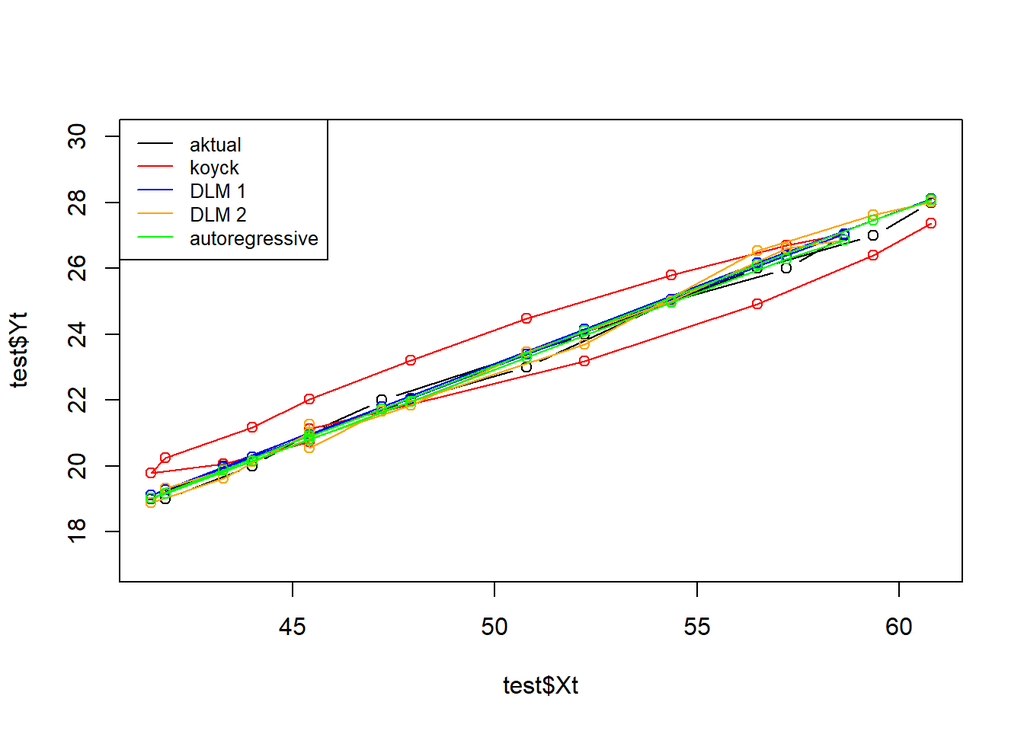

```r
par(mfrow=c(1,1))
plot(test$Xt, test$Yt, type="b", col="black", ylim=c(17,30))
points(test$Xt, fore.koyck$forecasts,col="red")
lines(test$Xt, fore.koyck$forecasts,col="red")
points(test$Xt, fore.dlm$forecasts,col="blue")
lines(test$Xt, fore.dlm$forecasts,col="blue")
points(test$Xt, fore.dlm2$forecasts,col="orange")
lines(test$Xt, fore.dlm2$forecasts,col="orange")
points(test$Xt, fore.ardl$forecasts,col="green")
lines(test$Xt, fore.ardl$forecasts,col="green")
legend("topleft",c("aktual", "koyck","DLM 1","DLM 2", "autoregressive"), lty=1, col=c("black","red","blue","orange","green"), cex=0.8)
```

Berdasarkan plot tersebut, terlihat bahwa plot yang paling mendekati data aktualnya adalah Model ARDL, sehingga dapat disimpulkan model terbaik dalam hal ini adalah model regresi ARDL.